# Análisis del presupuesto del Ayuntamiento de Madrid con Pandas

## Instalación de las librerías que vamos a utilizar

Pandas es una librería del programa Phyton

```python
!pip install pandas
```

## Configuramos la librería Pandas

Importamos la librería llamada Pandas y la denominamos como "pd" para usarla también otros notebooks de Phyton

```python
import pandas as pd
```

## Creamos las variables

La variable se crea con los datos adjuntos con el símbolo =

```python
url_covid = "https://datosabiertos.jcyl.es/web/jcyl/risp/es/salud/vacunas-covid-edad-sexo-provincia/1285032143059.csv"
```

## Verificamos que la variable se ha creado correctamente

```python
url_covid
```

```
'https://datosabiertos.jcyl.es/web/jcyl/risp/es/salud/vacunas-covid-edad-sexo-provincia/1285032143059.csv'
```

## Creamos un nuevo dataframe

```python
df = pd.read_csv(url_covid)
```

### Seguidamente, mostramos el dataframe creado de nuestra base de datos

```python
df
```

|  | fecha;provincia;Sexo;edad;dosis_administradas_acumulado;personas_vacunadas_ciclo_completo_acumulado;personas_vacunadas_1a_dosis_acumulado;porcentaje_residentes_1a_dosis;porcentaje_residentes_2a_dosis;… |
| --- | --- |
| 0 | 2021-03-02;Palencia;Mujer;0-15;1;0;1;;;;;PA |
| 1 | 2021-03-02;Palencia;Mujer;45-55;3121;1192;1929... |
| 2 | 2021-03-02;Palencia;Mujer;80-89;2317;906;1411;... |
| 3 | 2021-03-02;Salamanca;Hombre;35-44;1104;342;762... |
| 4 | 2021-03-02;Salamanca;Hombre;80-89;2211;841;137... |
| ... | ... |
| 73629 | 2021-05-01;Valladolid;Hombre;0-15;;0;1;0.0027;... |
| 73630 | 2021-05-01;Valladolid;Hombre;45-55;;1348;3681;... |
| 73631 | 2021-05-01;Valladolid;Hombre;56-59;;541;1288;8... |
| 73632 | 2021-05-01;Valladolid;Hombre;>89;;2354;2370;10... |
| 73633 | 2021-05-01;Valladolid;Mujer;18-24;;525;1409;9.... |

73634 rows × 1 columns

```python
df.info()
```

```
<class 'pandas.core.frame.DataFrame'>
RangeIndex: 73634 entries, 0 to 73633
Data columns (total 1 columns):
 #   Column                                                                                                                                                                                                                                                                              Non-Null Count  Dty…
---  ------                                                                                                                                                                                                                                                                              --------------  ---…
 0   fecha;provincia;Sexo;edad;dosis_administradas_acumulado;personas_vacunadas_ciclo_completo_acumulado;personas_vacunadas_1a_dosis_acumulado;porcentaje_residentes_1a_dosis;porcentaje_residentes_2a_dosis;personas_vacunadas_3a_dosis_acumulado;porcentaje_residentes_3a_dosis;sigla  73634 non-null  obj…
dtypes: object(1)
memory usage: 575.4+ KB
```

```python
df.head()
```

|  | fecha;provincia;Sexo;edad;dosis_administradas_acumulado;personas_vacunadas_ciclo_completo_acumulado;personas_vacunadas_1a_dosis_acumulado;porcentaje_residentes_1a_dosis;porcentaje_residentes_2a_dosis;… |
| --- | --- |
| 0 | 2021-03-02;Palencia;Mujer;0-15;1;0;1;;;;;PA |
| 1 | 2021-03-02;Palencia;Mujer;45-55;3121;1192;1929... |
| 2 | 2021-03-02;Palencia;Mujer;80-89;2317;906;1411;... |
| 3 | 2021-03-02;Salamanca;Hombre;35-44;1104;342;762... |
| 4 | 2021-03-02;Salamanca;Hombre;80-89;2211;841;137... |

```python
df.tail()
```

|  | fecha;provincia;Sexo;edad;dosis_administradas_acumulado;personas_vacunadas_ciclo_completo_acumulado;personas_vacunadas_1a_dosis_acumulado;porcentaje_residentes_1a_dosis;porcentaje_residentes_2a_dosis;… |
| --- | --- |
| 73629 | 2021-05-01;Valladolid;Hombre;0-15;;0;1;0.0027;... |
| 73630 | 2021-05-01;Valladolid;Hombre;45-55;;1348;3681;... |
| 73631 | 2021-05-01;Valladolid;Hombre;56-59;;541;1288;8... |
| 73632 | 2021-05-01;Valladolid;Hombre;>89;;2354;2370;10... |
| 73633 | 2021-05-01;Valladolid;Mujer;18-24;;525;1409;9.... |

## Cambio de base de datos

Hemos estado probando si el csv anterior sobre la vacunación en Castilla y León podíamos analizarlo para esta práctica, pero como se puede observar al no cargar bien la base de datos no podemos analizarla

Para solucionar esto, he escogido otra base de datos: el Presupuesto del Ayuntamiento de Madrid

```python
url_gasto = "https://presupuestosabiertos.madrid.es/es/municipio_madrid_gastosf.csv"
```

Verificamos que la variable está creada correctamente

```python
url_gasto
```

```
'https://presupuestosabiertos.madrid.es/es/municipio_madrid_gastosf.csv'
```

## Elaboración de un nuevo dataframe

Como ya hemos creado la nueva variable, creamos un nuevo dataframe para esta nueva base de datos

```python
df = pd.read_csv(url_gasto)
```

Se visualiza ahora el nuevo dataframe

```python
df
```

|  | Año | Id Política | Nombre Política | Id Programa | Nombre Programa | Presupuesto Gasto | Gasto Real |
| --- | --- | --- | --- | --- | --- | --- | --- |
| 0 | 2011 | 24 | Fomento del empleo | NaN | NaN | 5.421054e+07 | 47913922.89 |
| 1 | 2011 | 24 | Fomento del empleo | 24108 | Programa integrado de empleo | 1.189708e+06 | 1203749.90 |
| 2 | 2011 | 24 | Fomento del empleo | 24102 | Formación profesional para el empleo | 2.810259e+06 | 2348227.36 |
| 3 | 2011 | 24 | Fomento del empleo | 24103 | Políticas activas de empleo municipales | 9.539245e+06 | 8168288.15 |
| 4 | 2011 | 24 | Fomento del empleo | 24100 | Dirección y gestión administrativa de la Agenc... | 1.639677e+07 | 11349697.44 |
| ... | ... | ... | ... | ... | ... | ... | ... |
| 1815 | 2022 | 92 | Servicios de carácter general | 92210 | Oficina de coordinación | 8.678160e+05 | 179140.84 |
| 1816 | 2022 | 92 | Servicios de carácter general | 92008 | Planificación de recursos humanos | 1.142852e+07 | 2136730.36 |
| 1817 | 2022 | 92 | Servicios de carácter general | 92009 | Asesoría jurídica | 6.631859e+06 | 1219976.10 |
| 1818 | 2022 | 44 | Transporte público | NaN | NaN | 1.952004e+08 | NaN |
| 1819 | 2022 | 44 | Transporte público | 44110 | Promoción, control y desarrollo del transporte | 1.952004e+08 | NaN |

1820 rows × 7 columns

## Exploración del dataframe

Con el comando "df.info()" nos detalla la información de dicha tabla

```python
df.info()
```

```
<class 'pandas.core.frame.DataFrame'>
RangeIndex: 1820 entries, 0 to 1819
Data columns (total 7 columns):
 #   Column             Non-Null Count  Dtype
---  ------             --------------  -----
 0   Año                1820 non-null   int64
 1   Id Política        1820 non-null   int64
 2   Nombre Política    1820 non-null   object
 3   Id Programa        1597 non-null   object
 4   Nombre Programa    1597 non-null   object
 5   Presupuesto Gasto  1810 non-null   float64
 6   Gasto Real         1791 non-null   float64
dtypes: float64(2), int64(2), object(3)
memory usage: 99.7+ KB
```

## Cabecera

Con el comando "df.head() nos va a mostrar las primeras filas de la tabla. Dentro del paréntesis podemos delimitar el número de filas que queremos visualizar

```python
df.head()
```

|  | Año | Id Política | Nombre Política | Id Programa | Nombre Programa | Presupuesto Gasto | Gasto Real |
| --- | --- | --- | --- | --- | --- | --- | --- |
| 0 | 2011 | 24 | Fomento del empleo | NaN | NaN | 54210544.09 | 47913922.89 |
| 1 | 2011 | 24 | Fomento del empleo | 24108 | Programa integrado de empleo | 1189708.00 | 1203749.90 |
| 2 | 2011 | 24 | Fomento del empleo | 24102 | Formación profesional para el empleo | 2810259.00 | 2348227.36 |
| 3 | 2011 | 24 | Fomento del empleo | 24103 | Políticas activas de empleo municipales | 9539245.47 | 8168288.15 |
| 4 | 2011 | 24 | Fomento del empleo | 24100 | Dirección y gestión administrativa de la Agenc... | 16396774.95 | 11349697.44 |

## Cola

A continuación con el comando "df.tail()" se visualizarán las últimas filas de la tabla

```python
df.tail ()
```

|  | Año | Id Política | Nombre Política | Id Programa | Nombre Programa | Presupuesto Gasto | Gasto Real |
| --- | --- | --- | --- | --- | --- | --- | --- |
| 1815 | 2022 | 92 | Servicios de carácter general | 92210 | Oficina de coordinación | 867816.0 | 179140.84 |
| 1816 | 2022 | 92 | Servicios de carácter general | 92008 | Planificación de recursos humanos | 11428520.0 | 2136730.36 |
| 1817 | 2022 | 92 | Servicios de carácter general | 92009 | Asesoría jurídica | 6631859.0 | 1219976.10 |
| 1818 | 2022 | 44 | Transporte público | NaN | NaN | 195200412.0 | NaN |
| 1819 | 2022 | 44 | Transporte público | 44110 | Promoción, control y desarrollo del transporte | 195200412.0 | NaN |

## Columnas

Para saber el nombre de las columnas que conforman el conjunto de nuestra tabla, se realizará con el comando "df.columns"

```python
df.columns
```

```
Index(['Año', 'Id Política', 'Nombre Política', 'Id Programa',
       'Nombre Programa', 'Presupuesto Gasto', 'Gasto Real'],
      dtype='object')
```

Además, este comando nos permite mostrar solo las columnas de la que queramos visualizar datos. Para ello, vamos a mostrar solo las columnas "Presupuesto Gasto" y "Columna Real"

### Presupuesto Gasto

```python
df["Presupuesto Gasto"]
```

```
0       5.421054e+07
1       1.189708e+06
2       2.810259e+06
3       9.539245e+06
4       1.639677e+07
            ...
1815    8.678160e+05
1816    1.142852e+07
1817    6.631859e+06
1818    1.952004e+08
1819    1.952004e+08
Name: Presupuesto Gasto, Length: 1820, dtype: float64
```

### Gasto real

```python
df["Gasto Real"]
```

```
0       47913922.89
1        1203749.90
2        2348227.36
3        8168288.15
4       11349697.44
           ...
1815      179140.84
1816     2136730.36
1817     1219976.10
1818            NaN
1819            NaN
Name: Gasto Real, Length: 1820, dtype: float64
```

Al igual que se puede mostrar una sola columna, también se puede visualizar una sola fila de una columna. Para ejemplificarlo, mostraré la fila 10

```python
df["Gasto Real"][10]
```

```
708489668.82
```

## Visualizamos las variables estadísticas

```python
df.describe()
```

|  | Año | Id Política | Presupuesto Gasto | Gasto Real |
| --- | --- | --- | --- | --- |
| count | 1820.000000 | 1820.000000 | 1.810000e+03 | 1.791000e+03 |
| mean | 2016.836264 | 49.826923 | 7.182683e+07 | 5.957415e+07 |
| std | 3.477818 | 33.819985 | 1.678057e+08 | 1.537209e+08 |
| min | 2011.000000 | 1.000000 | 1.226000e+03 | 3.469100e+02 |
| 25% | 2014.000000 | 17.000000 | 2.907778e+06 | 1.794289e+06 |
| 50% | 2017.000000 | 33.000000 | 1.261723e+07 | 8.942395e+06 |
| 75% | 2020.000000 | 91.000000 | 6.405222e+07 | 4.868009e+07 |
| max | 2022.000000 | 93.000000 | 2.344455e+09 | 2.343548e+09 |

## Ordenamos el dataframe por columnas

Esta función se haraá con el comando "df.set_index()

```python
df.set_index('Año')
```

| Año | Id Política | Nombre Política | Id Programa | Nombre Programa | Presupuesto Gasto | Gasto Real |
| --- | --- | --- | --- | --- | --- | --- |
| 2011 | 24 | Fomento del empleo | NaN | NaN | 5.421054e+07 | 47913922.89 |
| 2011 | 24 | Fomento del empleo | 24108 | Programa integrado de empleo | 1.189708e+06 | 1203749.90 |
| 2011 | 24 | Fomento del empleo | 24102 | Formación profesional para el empleo | 2.810259e+06 | 2348227.36 |
| 2011 | 24 | Fomento del empleo | 24103 | Políticas activas de empleo municipales | 9.539245e+06 | 8168288.15 |
| 2011 | 24 | Fomento del empleo | 24100 | Dirección y gestión administrativa de la Agenc... | 1.639677e+07 | 11349697.44 |
| ... | ... | ... | ... | ... | ... | ... |
| 2022 | 92 | Servicios de carácter general | 92210 | Oficina de coordinación | 8.678160e+05 | 179140.84 |
| 2022 | 92 | Servicios de carácter general | 92008 | Planificación de recursos humanos | 1.142852e+07 | 2136730.36 |
| 2022 | 92 | Servicios de carácter general | 92009 | Asesoría jurídica | 6.631859e+06 | 1219976.10 |
| 2022 | 44 | Transporte público | NaN | NaN | 1.952004e+08 | NaN |
| 2022 | 44 | Transporte público | 44110 | Promoción, control y desarrollo del transporte | 1.952004e+08 | NaN |

1820 rows × 6 columns

```python
df.set_index('Año')['Presupuesto Gasto']
```

```
Año
2011    5.421054e+07
2011    1.189708e+06
2011    2.810259e+06
2011    9.539245e+06
2011    1.639677e+07
            ...
2022    8.678160e+05
2022    1.142852e+07
2022    6.631859e+06
2022    1.952004e+08
2022    1.952004e+08
Name: Presupuesto Gasto, Length: 1820, dtype: float64
```

## Elaboramos un gráfico con las columnas Año y Presupuesto Gasto

Como hemos indexados los datos según las variables "Año" y "Presupuesto Gasto", con el comando ".plot" se creará un gráfico. Con el comando "title=" permitirá la opción de poner un título a nuestro gráfico

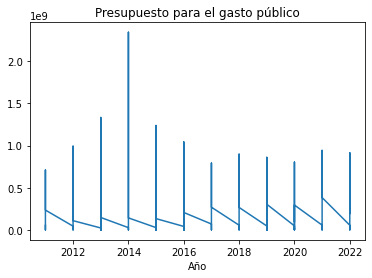

```python
df.set_index('Año')['Presupuesto Gasto'].plot(title='Presupuesto para el gasto público')
```

## Elaboramos otro gráfico con las variables "Año" y "Gasto Real"

Ahora en este caso indexamos los datos según las variables "Año" y "Gasto Real"

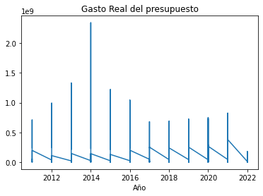

```python
df.set_index('Año')['Gasto Real'].plot(title='Gasto Real del presupuesto')
```

## Comparación de Presupuesto Gasto y Gasto Real

Vamos a comparar los datos de Presupuesto Gasto y Gasto Real tomando como referencia el año.

Para dicha comparación, definimos dos nuevas variables

```python
gastos_pres = df.set_index('Año')['Presupuesto Gasto']
gastos_real = df.set_index('Año')['Gasto Real']
```

```python
vs = pd.concat([gastos_pres,gastos_real],axis=1)
vs
```

| Año | Presupuesto Gasto | Gasto Real |
| --- | --- | --- |
| 2011 | 5.421054e+07 | 47913922.89 |
| 2011 | 1.189708e+06 | 1203749.90 |
| 2011 | 2.810259e+06 | 2348227.36 |
| 2011 | 9.539245e+06 | 8168288.15 |
| 2011 | 1.639677e+07 | 11349697.44 |
| ... | ... | ... |
| 2022 | 8.678160e+05 | 179140.84 |
| 2022 | 1.142852e+07 | 2136730.36 |
| 2022 | 6.631859e+06 | 1219976.10 |
| 2022 | 1.952004e+08 | NaN |
| 2022 | 1.952004e+08 | NaN |

1820 rows × 2 columns

## Elaboramos un gráfico comparativo

Como hemos concatenado los datos, procedemos a crear un gráfico.

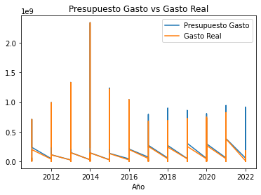

```python
vs.columns = ['Presupuesto Gasto', 'Gasto Real']
vs.plot(title='Presupuesto Gasto vs Gasto Real')
```

## Lo guardamos en un formato CSV

```python
vs.to_csv('presupuesto.madrid')
```

Comprobamos que se ha creado con el comando "ls"

```python
!ls
```

```
 api-pandas-folium.ipynb  'probando con r.ipynb'
 escit.png		  'python-api-covid19-pandas 1.ipynb'
 esvit.csv		   python-api-covid19-pandas.ipynb
 esvsit.csv		   seaborn-data
 evsit.png		   Shared_Resources
 phyton-pruebas.ipynb	   Untitled1.ipynb
 presupuesto.madrid	   Untitled.ipynb
```

Guardamos el matplotlib.pylot y se renombra como plt. Además, guardaremos la imagen del gráfico

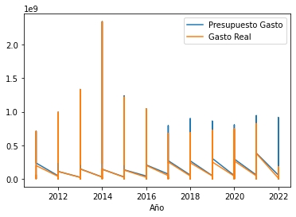

```python
import matplotlib.pyplot as plt
vs.plot()
plt.savefig('presupuesto.png')
```